# Classification of Human Activity Recognition

Xiang Wang, Master Student in Applied Statistics, Department of Statistics, Penn State University

December 11, 2015

## Abstract

Wearable devices such as watch, band, ring and so on from big tech companies are starting to gain some popularity in the mainstream customers. They track and monitor the human activities such as jogging, walking, sleeping and so on. The raw data were collected from accelerometers on the belt, forearm, arm, and dumbell of six young health participants in five different **manners**. The objective of this project is to build a model to precisely predict or classify the manner each person did the exercise. Four classification methods are used: multinomial logit regression (MR), linear discriminant analysis (LDA), quadratic discriminant analysis (QDA) and random forest (RF). Results show that **random forest** method yields significantly higher prediction accuracy, sensitivity and specificity than the other three methods. Thus, I would prefer to this method to predict potential manners with new testing data.

### 1. Introduction

As an MAS student, I am specifically interested in apply data mining skills to meet the industry need for dealing with big data. This is also my potential job target when I will graduate in May 2016. One of the emerging markets for high-tech industry is wearable devices which include watch, band, ring and so on. Wearable devices are starting to gain some popularity in the mainstream customers as companies such as *Apple*, *Jawbone*, *Nike*, and *Fitbit* have debut their wearable products. Now it is relatively not expensive to collect a large amount of data about personal activity. These type of devices are part of the quantified self movement – a group of enthusiasts who take measurements about themselves regularly to improve their health, to find patterns in their behavior, or because they are tech geeks.

### 2. Raw Data

The raw data were collected from accelerometers on the belt, forearm, arm, and dumbell of six young health participants. They were asked to perform one set of 10 repetitions of the Unilateral Dumbbell Biceps Curl in five different **manners** (the last variable “classe” in the data set): exactly according to the specification (**Class A**), throwing the elbows to the front (**Class B**), lifting the dumbbell only halfway (**Class C**), lowering the dumbbell only halfway (**Class D**) and throwing the hips to the front (**Class E**).

Class A corresponds to the specified execution of the exercise, while the other 4 classes correspond to common mistakes. Participants were supervised by an experienced weight lifter to make sure the execution complied to the manner they were supposed to simulate. The exercises were performed by six male participants aged between 20-28 years, with little weight lifting experience. All participants could easily simulate the mistakes in a safe and controlled manner by using a relatively light dumbbell (1.25kg).

More information about the data is available from the website here: http://groupware.les.inf.puc-rio.br/har (see the section on the Weight Lifting Exercise Dataset). The original data for this project are available here: http://groupware.les.inf.puc-rio.br/static/WLE/WearableComputing_weight_lifting_exercises_biceps_curl_variations.csv. **Reference:** Velloso, E.; Bulling, A.; Gellersen, H.; Ugulino, W.; Fuks, H. Qualitative Activity Recognition of Weight Lifting Exercises. Proceedings of 4th International Conference in Cooperation with SIGCHI (Augmented Human ’13) . Stuttgart, Germany: ACM SIGCHI, 2013.

### 4. Data Preparation

### 4.1 Raw Data Preparation

```r
data <- read.csv("WLE.csv")
names(data); dim(data)
```

By running str(data) (not show the result due to space), we can see many numeric variables (for example, kurtosis_yaw_belt) are read as factor due to some characters (“#DIV/0!”); in addition, some variables have a lot of missing values. First, I need to reload the data by ignoring “#DIV/0!” values and change these variables to numeric values for the specified columns (i.e. column 8 to the second last column).

```r
data <- read.csv("WLE.csv", header=TRUE, sep=',', na.strings=c("#DIV/0!"))
data1 <- data
for(i in c(7:ncol(data1)-1)) {
  data1[,i]=as.numeric(as.character(data1[,i]))
}
```

To deal with the missing values, we can choose those only the column with a 100% completion rate. Then, I export data2 as a tab delimited text file (newWLE.txt) that is ready for the following steps.

```r
# discard the first 7 variables which appears to be not important
data2 <- data1[colSums(is.na(data1))==0][-(1:7)]
# remove rows with missing values
sum(is.na(data2)) # no missing values now
# export data2 as a tab delimited text file
write.table(data2, "newWLE.txt", sep="\t")
```

### 4.2 Data Preparation for Model Selection

In this part, I will show the details on how train and validation data for model selections are generated.

```r
library(caret) # need createDataPartition function from 'caret' package
```

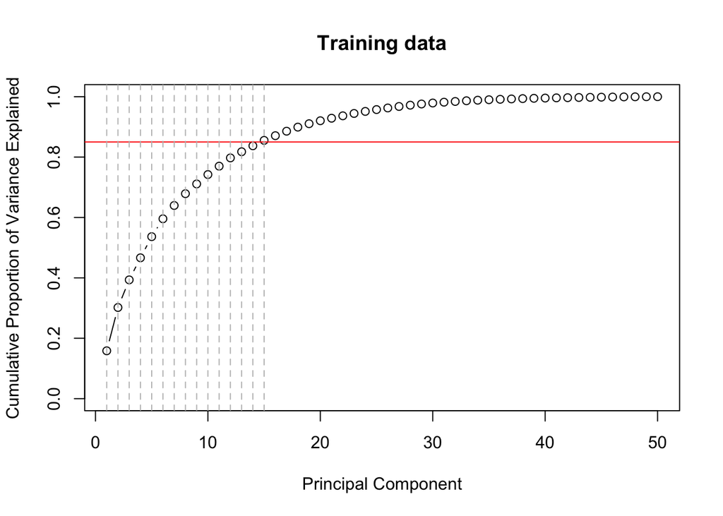

```r
data <- read.csv("newWLE.txt", header=TRUE, sep='\t')
# use the original five categories instead of two catergories in the midterm report
# length(which(data$classe=="A")) # 11159
# length(which(data$classe=="B")) # 7593
# length(which(data$classe=="C")) # 6844
# length(which(data$classe=="D")) # 6432
# length(which(data$classe=="E")) # 7214
# dim(data) # 39242  51
# partition data into training and test data (7:3)
set.seed(1200)
inTrain <- createDataPartition(y=data$classe, p=.7,list=F)
train <- data[inTrain,]; valid <- data[-inTrain,]

Y.train <- as.matrix(train[,dim(train)[2]]) # response variable is in last column
Y.valid <- as.matrix(valid[,dim(valid)[2]]) # response variable is in last column
n.train <- dim(train)[1] # sample size 27472
n.valid <- dim(valid)[1] # sample size 11770
k.train <- length(unique(Y.train)) # number of classes is 5 (A B C D E)
k.valid <- length(unique(Y.valid)) # number of classes is 5 (A B C D E)

# scale the training data and then scale the validation data using the mean and variance of the training data.
x.train.mean <- apply(train[,-51], 2, mean)
x.train.sd <- apply(train[,-51], 2, sd)
# standardize training data to have mean 0 and sd 1
X.train <- t((t(train[,-51])-x.train.mean)/x.train.sd)
# apply(X.train, 2, mean) # check zero mean and they are 0s
# apply(X.train, 2, sd) # check sd and they are 1s

# standardize validation data using training mean and sd
X.valid <- t((t(valid[,-51])-x.train.mean)/x.train.sd)

pca.train <- princomp(X.train, cor=T) # principal components analysis using correlation matrix
# summary(pca.train) # the first 15 components consist of ~ 85% of varaiance
pr.var <- pca.train$sdev^2; pve <- pr.var/sum(pr.var)
plot(cumsum(pve), xlab="Principal Component", ylab="Cumulative Proportion of Variance Explained", main="Training data", ylim=c(0,1),type='b')
abline(h=0.85,col="red"); abline(v=1:15,col="grey",lty=2)
```

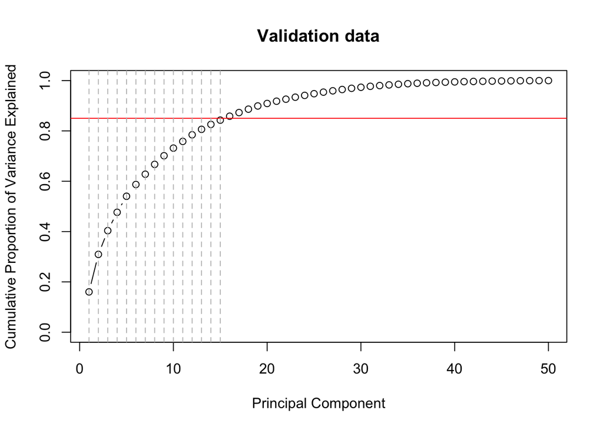

```r
pc.comp.train <- pca.train$scores
pc.comp1.train <- pc.comp.train[,1]; pc.comp2.train <- pc.comp.train[,2]
pc.comp3.train <- pc.comp.train[,3]; pc.comp4.train <- pc.comp.train[,4]
pc.comp5.train <- pc.comp.train[,5]; pc.comp6.train <- pc.comp.train[,6]
pc.comp7.train <- pc.comp.train[,7]; pc.comp8.train <- pc.comp.train[,8]
pc.comp9.train <- pc.comp.train[,9]; pc.comp10.train <- pc.comp.train[,10]
pc.comp11.train <- pc.comp.train[,11]; pc.comp12.train <- pc.comp.train[,12]
pc.comp13.train <- pc.comp.train[,13]; pc.comp14.train <- pc.comp.train[,14]
pc.comp15.train <- pc.comp.train[,15]
X.train <- cbind(pc.comp1.train, pc.comp2.train, pc.comp3.train, pc.comp4.train, pc.comp5.train, pc.comp6.train, pc.comp7.train, pc.comp8.train, pc.comp9.train, pc.comp10.train, pc.comp11.train, pc.comp12.train, pc.comp13.train, pc.comp14.train, pc.comp15.train)
data.train <- as.data.frame(cbind(Y.train, X.train))
names(data.train) <- c("Y", "X1", "X2", "X3", "X4", "X5", "X6", "X7", "X8", "X9", "X10", "X11", "X12", "X13", "X14", "X15")

pca.valid <- princomp(X.valid, cor=T) # principal components analysis using correlation matrix
# summary(pca.valid) # the first 15 components consist of ~ 85% of varaiance
pr.var1 <- pca.valid$sdev^2; pve1 <- pr.var1/sum(pr.var1)
plot(cumsum(pve1), xlab="Principal Component", ylab="Cumulative Proportion of Variance Explained", main="Validation data", ylim=c(0,1),type='b')
abline(h=0.85,col="red"); abline(v=1:15,col="grey",lty=2)
```

```r
pc.comp.valid <- pca.valid$scores
pc.comp1.valid <- pc.comp.valid[,1]; pc.comp2.valid <- pc.comp.valid[,2]
pc.comp3.valid <- pc.comp.valid[,3]; pc.comp4.valid <- pc.comp.valid[,4]
pc.comp5.valid <- pc.comp.valid[,5]; pc.comp6.valid <- pc.comp.valid[,6]
pc.comp7.valid <- pc.comp.valid[,7]; pc.comp8.valid <- pc.comp.valid[,8]
pc.comp9.valid <- pc.comp.valid[,9]; pc.comp10.valid <- pc.comp.valid[,10]
pc.comp11.valid <- pc.comp.valid[,11]; pc.comp12.valid <- pc.comp.valid[,12]
pc.comp13.valid <- pc.comp.valid[,13]; pc.comp14.valid <- pc.comp.valid[,14]
pc.comp15.valid <- pc.comp.valid[,15]
X.valid <- cbind(pc.comp1.valid, pc.comp2.valid, pc.comp3.valid, pc.comp4.valid, pc.comp5.valid, pc.comp6.valid, pc.comp7.valid, pc.comp8.valid,  pc.comp9.valid, pc.comp10.valid, pc.comp11.valid, pc.comp12.valid, pc.comp13.valid, pc.comp14.valid, pc.comp15.valid)
data.valid <- as.data.frame(cbind(Y.valid, X.valid))
names(data.valid) <- c("Y", "X1", "X2", "X3", "X4","X5", "X6", "X7", "X8", "X9", "X10", "X11", "X12", "X13", "X14", "X15")

write.table(data.train, "train.txt", sep="\t")
write.table(data.valid, "valid.txt", sep="\t")
```

### 5 Model Selection and Evaluation

### 5.1 Model a: Multinomial logit regression (MR) analysis using multinom function in the nnet package

```r
library(caret) # need confusionMatrix function in 'caret' package
data.train <- read.csv("train.txt", header=TRUE, sep='\t')
data.valid <- read.csv("valid.txt", header=TRUE, sep='\t')
library(nnet) # package that can do multinomial Log-Linear Models
model.lr.train <- multinom(Y ~ ., data.train) # Fits multinomial log-linear models using multinom function
pred.class.train <- predict(model.lr.train)
confusionMatrix(pred.class.train, data.train$Y) # confusion matrix for training data
```

```
## Confusion Matrix and Statistics
##
##           Reference
## Prediction    A    B    C    D    E
##          A 5328 1401 2195  631  881
##          B  327 1989  417  714  816
##          C  659  581 1283  459  396
##          D 1025  740  545 2204  689
##          E  473  605  351  495 2268
##
## Overall Statistics
##
##                Accuracy : 0.4758
##                  95% CI : (0.4699, 0.4818)
##     No Information Rate : 0.2844
##     P-Value [Acc > NIR] : < 2.2e-16
##
##                   Kappa : 0.3292
##  Mcnemar's Test P-Value : < 2.2e-16
##
## Statistics by Class:
##
##                      Class: A Class: B Class: C Class: D Class: E
## Sensitivity            0.6820   0.3742   0.2678  0.48945  0.44911
## Specificity            0.7402   0.8974   0.9076  0.86943  0.91419
## Pos Pred Value         0.5105   0.4666   0.3798  0.42360  0.54103
## Neg Pred Value         0.8542   0.8567   0.8544  0.89676  0.88050
## Prevalence             0.2844   0.1935   0.1744  0.16391  0.18382
## Detection Rate         0.1939   0.0724   0.0467  0.08023  0.08256
## Detection Prevalence   0.3799   0.1552   0.1230  0.18939  0.15259
## Balanced Accuracy      0.7111   0.6358   0.5877  0.67944  0.68165
```

```r
# The prediction accurancy for the five classes ranges from ~ 0.6 to ~ 0.7; sensitivity ranges from 0.3 to 0.7; specificity ranges from 0.7 to 0.9.

model.lr.valid <- multinom(Y ~ ., data.valid) # Fits multinomial log-linear models using multinom function
pred.class.valid <- predict(model.lr.valid)
confusionMatrix(pred.class.valid, data.valid$Y) # confusion matrix for validation data
```

```
## Confusion Matrix and Statistics
##
##           Reference
## Prediction    A    B    C    D    E
##          A 2361  614  868  241  310
##          B  146  831  129  306  346
##          C  261  268  660  175  190
##          D  452  331  276 1031  264
##          E  127  233  120  176 1054
##
## Overall Statistics
##
##                Accuracy : 0.5044
##                  95% CI : (0.4953, 0.5135)
##     No Information Rate : 0.2844
##     P-Value [Acc > NIR] : < 2.2e-16
##
##                   Kappa : 0.3666
##  Mcnemar's Test P-Value : < 2.2e-16
##
## Statistics by Class:
##
##                      Class: A Class: B Class: C Class: D Class: E
## Sensitivity            0.7054   0.3650  0.32148   0.5345  0.48706
## Specificity            0.7586   0.9023  0.90800   0.8656  0.93171
## Pos Pred Value         0.5373   0.4727  0.42471   0.4380  0.61637
## Neg Pred Value         0.8663   0.8556  0.86365   0.9046  0.88966
## Prevalence             0.2844   0.1935  0.17443   0.1639  0.18386
## Detection Rate         0.2006   0.0706  0.05607   0.0876  0.08955
## Detection Prevalence   0.3733   0.1494  0.13203   0.2000  0.14528
## Balanced Accuracy      0.7320   0.6337  0.61474   0.7000  0.70939
```

```r
# The prediction accurancy for the five classes ranges from ~ 0.6 to ~ 0.7; sensitivity ranges from 0.3 to 0.7; specificity ranges from 0.7 to 0.9.
```

### Model b: Linear discriminant analysis (LDA) using lda function in the MASS package

```r
library(MASS)
model.lda.train <- lda(Y ~ ., data.train)
pred.lda.train <- predict(model.lda.train)$class
confusionMatrix(pred.lda.train, data.train$Y) # confusion matrix for training data
```

```
## Confusion Matrix and Statistics
##
##           Reference
## Prediction    A    B    C    D    E
##          A 5237 1354 2083  539  826
##          B  412 2081  502  915  868
##          C  720  641 1300  500  356
##          D 1037  695  560 2139  767
##          E  406  545  346  410 2233
##
## Overall Statistics
##
##                Accuracy : 0.4728
##                  95% CI : (0.4669, 0.4788)
##     No Information Rate : 0.2844
##     P-Value [Acc > NIR] : < 2.2e-16
##
##                   Kappa : 0.3265
##  Mcnemar's Test P-Value : < 2.2e-16
##
## Statistics by Class:
##
##                      Class: A Class: B Class: C Class: D Class: E
## Sensitivity            0.6704  0.39146  0.27134  0.47502  0.44218
## Specificity            0.7557  0.87827  0.90225  0.86682  0.92387
## Pos Pred Value         0.5217  0.43554  0.36963  0.41150  0.56675
## Neg Pred Value         0.8523  0.85745  0.85427  0.89387  0.88029
## Prevalence             0.2844  0.19351  0.17440  0.16391  0.18382
## Detection Rate         0.1906  0.07575  0.04732  0.07786  0.08128
## Detection Prevalence   0.3654  0.17392  0.12802  0.18921  0.14342
## Balanced Accuracy      0.7131  0.63487  0.58680  0.67092  0.68302
```

```r
# The prediction accurancy for the five classes ranges from ~ 0.6 to ~ 0.7; sensitivity ranges from 0.3 to 0.7; specificity ranges from 0.7 to 0.9.

model.lda.valid <- lda(Y ~ ., data.valid)
pred.lda.valid <- predict(model.lda.valid)$class
confusionMatrix(pred.lda.valid, data.valid$Y) # confusion matrix for validation data
```

```
## Confusion Matrix and Statistics
##
##           Reference
## Prediction    A    B    C    D    E
##          A 2290  581  837  223  316
##          B  204  880  157  330  357
##          C  318  288  664  216  158
##          D  446  302  273 1000  272
##          E   89  226  122  160 1061
##
## Overall Statistics
##
##                Accuracy : 0.5008
##                  95% CI : (0.4918, 0.5099)
##     No Information Rate : 0.2844
##     P-Value [Acc > NIR] : < 2.2e-16
##
##                   Kappa : 0.3629
##  Mcnemar's Test P-Value : < 2.2e-16
##
## Statistics by Class:
##
##                      Class: A Class: B Class: C Class: D Class: E
## Sensitivity            0.6842  0.38647  0.32343  0.51840  0.49030
## Specificity            0.7677  0.88960  0.89915  0.86861  0.93785
## Pos Pred Value         0.5392  0.45643  0.40389  0.43611  0.63993
## Neg Pred Value         0.8595  0.85806  0.86283  0.90197  0.89092
## Prevalence             0.2844  0.19346  0.17443  0.16389  0.18386
## Detection Rate         0.1946  0.07477  0.05641  0.08496  0.09014
## Detection Prevalence   0.3608  0.16381  0.13968  0.19482  0.14087
## Balanced Accuracy      0.7259  0.63804  0.61129  0.69351  0.71407
```

```r
# The prediction accurancy for the five classes ranges from ~ 0.6 to ~ 0.7; sensitivity ranges from 0.3 to 0.7; specificity ranges from 0.8 to 0.9.
```

### Model c: Quadratic discriminant analysis (QDA) using qda function in the MASS package

```r
model.qda.train <- qda(Y ~ ., data.train)
pred.qda.train <- predict(model.qda.train)$class
confusionMatrix(pred.qda.train, data.train$Y) # confusion matrix for training data
```

```
## Confusion Matrix and Statistics
##
##           Reference
## Prediction    A    B    C    D    E
##          A 3700  449  147  100   61
##          B  208 2332  257   46  226
##          C 2819 1290 3970 1413  555
##          D  876  274  263 2609  638
##          E  209  971  154  335 3570
##
## Overall Statistics
##
##                Accuracy : 0.589
##                  95% CI : (0.5832, 0.5948)
##     No Information Rate : 0.2844
##     P-Value [Acc > NIR] : < 2.2e-16
##
##                   Kappa : 0.4898
##  Mcnemar's Test P-Value : < 2.2e-16
##
## Statistics by Class:
##
##                      Class: A Class: B Class: C Class: D Class: E
## Sensitivity            0.4736  0.43868   0.8286  0.57939   0.7069
## Specificity            0.9615  0.96674   0.7321  0.91071   0.9256
## Pos Pred Value         0.8302  0.75986   0.3951  0.55987   0.6814
## Neg Pred Value         0.8213  0.87772   0.9529  0.91697   0.9334
## Prevalence             0.2844  0.19351   0.1744  0.16391   0.1838
## Detection Rate         0.1347  0.08489   0.1445  0.09497   0.1300
## Detection Prevalence   0.1622  0.11171   0.3657  0.16963   0.1907
## Balanced Accuracy      0.7176  0.70271   0.7804  0.74505   0.8162
```

```r
# The prediction accurancy for the five classes ranges from ~ 0.7 to ~ 0.8; sensitivity ranges from 0.4 to 0.8; specificity ranges from 0.7 to 0.9.

model.qda.valid <- lda(Y ~ ., data.valid)
pred.qda.valid <- predict(model.qda.valid)$class
confusionMatrix(pred.qda.valid, data.valid$Y) # confusion matrix for validation data
```

```
## Confusion Matrix and Statistics
##
##           Reference
## Prediction    A    B    C    D    E
##          A 2290  581  837  223  316
##          B  204  880  157  330  357
##          C  318  288  664  216  158
##          D  446  302  273 1000  272
##          E   89  226  122  160 1061
##
## Overall Statistics
##
##                Accuracy : 0.5008
##                  95% CI : (0.4918, 0.5099)
##     No Information Rate : 0.2844
##     P-Value [Acc > NIR] : < 2.2e-16
##
##                   Kappa : 0.3629
##  Mcnemar's Test P-Value : < 2.2e-16
##
## Statistics by Class:
##
##                      Class: A Class: B Class: C Class: D Class: E
## Sensitivity            0.6842  0.38647  0.32343  0.51840  0.49030
## Specificity            0.7677  0.88960  0.89915  0.86861  0.93785
## Pos Pred Value         0.5392  0.45643  0.40389  0.43611  0.63993
## Neg Pred Value         0.8595  0.85806  0.86283  0.90197  0.89092
## Prevalence             0.2844  0.19346  0.17443  0.16389  0.18386
## Detection Rate         0.1946  0.07477  0.05641  0.08496  0.09014
## Detection Prevalence   0.3608  0.16381  0.13968  0.19482  0.14087
## Balanced Accuracy      0.7259  0.63804  0.61129  0.69351  0.71407
```

```r
# The prediction accurancy for the five classes ranges from ~ 0.6 to ~ 0.7; sensitivity ranges from 0.3 to 0.7; specificity ranges from 0.8 to 0.9.
```